# Numerical Inverse Laplace transforms

## What is a Laplace transform?

- The Laplace transform of $f(t):[0,\infty)\to \mathbb R$ is \begin{equation}

  ```
    \widehat f(s) = \mathcal L(s)\{f(t)\} = \int_{t=0}^\infty e^{-st} f(t) dt
  ```

  \end{equation} for values of $s$ where this integral converges.
- When $f(t)$ is a density function of a r.v. $X$ \begin{align}

  ```
    \mathbb E[e^{-Xs}]=\int_{t=0}^\infty e^{-st} f(t) dt.
  ```

  \end{align}
- Let $E^s\sim exp(s)$ be an exponential r.v. with rate $s$ and distribution function \begin{align}

  ```
    \mathbb P(E^s\leq t) = 1 - e^{-st}
  ```

  \end{align} hence \begin{align}

  ```
    \mathbb P(E^s > t) = e^{-st}.
  ```

  \end{align} Substituting into the Laplace transform, \begin{align}

  ```
    \int_{t=0}^\infty e^{-st} f(t) dt = \int_{t=0}^\infty\mathbb P(E^s > t) \mathbb P(X\in dt) dt = \mathbb P(E^s > X);
  ```

  \end{align} a probabilistic interpretation.
- For example $f(t)=t^n$ then \begin{equation} \mathcal L(s)\{f\} = \int_{t=0}^\infty e^{-st}t^ndt = \frac{n!}{s^{n+1}}. \end{equation}

**Multidimensional Laplace transforms**

If $f(t_1,t_2):[0,\infty)\to \mathbb R$ then \begin{equation} \mathcal L(s_1,s_2)\{f(t_2,t_2)\} = \int_{t_1=0}^\infty\int_{t_2=0}^\infty e^{-s_1t_1}e^{-s_2t_2} f(t_1,t_2)dt_1dt_2. \end{equation}

## Why is it useful?

**Convolution theorem**

Let $g(t), f(t)$ be functions. The convolution is \begin{equation} (g*f)(t) = \int_{u=0}^t f(u)g(t-u) du. \end{equation} Convolution theorem says \begin{equation} \mathcal L(s)\{g*f\} = \mathcal L(s)\{g\} \cdot \mathcal L(s)\{f\}. \end{equation}

**Differentiation theorem**

\begin{equation} \mathcal L(s)\{f'(t)\} = s\mathcal L(s)\{f(t)\} - f(0). \end{equation}

Lots of other properties.

**Uniqueness**

If $f,g$ are functions with \begin{equation} \mathcal L(s)\{f\} = \mathcal L(s)\{g\} \end{equation} for $s>c$ for some $c\in\mathbb R$ then $f(t)=g(t)$ (almost everywhere), e.g. if $f$ and $g$ are continuous.

## Inversion formulas

**The Bromwich Inversion Theorem**

If \begin{equation} \widehat f(s) = \mathcal L(s)\{f(t)\} = \int_{t=0}^\infty e^{-st} f(t) dt, \end{equation} then \begin{equation} f(t) = \frac{1}{2\pi i} \int_{s=c-i\infty}^{c+i\infty} e^{st}\widehat f(s) ds, \end{equation} where $c>\gamma$ is a constant and $\gamma$ is the smallest real parf for which the Laplace transform converges.

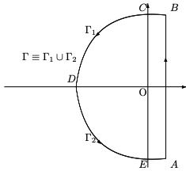

**2D Bromwich Inversion Theorem**

If \begin{equation} \widehat f(s_1,s_2) = \mathcal L(s_1,s_2)\{f(t_1,t_2)\} = \int_{t_1=0}^\infty\int_{t_2=0}^\infty e^{-s_1t_1} e^{-s_2t_2} f(t_1,t_2) dt_2dt_1, \end{equation} then \begin{equation} f(t_1,t_2) = \left(\frac{1}{2\pi i}\right)^2 \int_{s_1=c_1-i\infty}^{c_1+i\infty}\int_{s_2=c_2-i\infty}^{c_2+i\infty} e^{s_1t_1}e^{s_2t_2}\widehat f(s_1,s_2) ds_2ds_1. \end{equation}

**Post-Widder Inversion Formula**

\begin{equation} f(t) = \lim_{n\to\infty} \frac{(-1)^n}{n!} \left(\frac{n}{t}\right)^{n+1} \widehat f^{(n)}\left(\frac{n}{t}\right), \end{equation}

at continuity points of $f(t)$.

## Numerical inversion methods

## Abate-Whitt framework

Recall \begin{equation} f(t) = \frac{1}{2\pi i}\int_{c-i\infty}^{c+i\infty} e^{st}\widehat f(s)ds. \end{equation} is an inverse Laplace transform.

The Abate-Whitt framework considers approximations of the form \begin{equation} f(t) \approx \frac{1}{t}\sum_{k=0}^n \eta_k \widehat f\left(\beta_k/t\right). \end{equation}

Different schemes are formed by choosing different $\eta_k$ and $\beta_k$.

**Talbot**

- Considers an alternate contour and uses a trapezoidal rule to approximate the integral.

**Euler**

- Observes \begin{equation}

  ```
    f(t) = \frac{1}{2\pi i}\int_{c-i\infty}^{c+i\infty} e^{st}\widehat f(s)ds = \frac{e^{ct}}{2\pi i}\int_{-\infty}^{\infty} e^{ixt}\widehat f(c+ix)dx,
  ```

  \end{equation} the latter being an inverse fourier transform.

**CME**

- Observe \begin{equation}

  ```
    f(t) \approx \frac{1}{t}\sum_{k=0}^n \eta_k \widehat f\left(\frac{\beta_k}{t}\right)
    \\= \sum_{k=0}^n \eta_k \int_{u=0}^\infty \exp{\left(\frac{\beta_k}{t}u\right)}f(u)du
    \\= \int_{u=0}^\infty f(ut) g_n(u)du
  ```

  \end{equation} where \begin{equation}

  ```
    g_n(u) = \sum_{k=0}^n \eta_k e^{\beta_ku}.
  ```

  \end{equation} If $g_n(u)$ were a dirac delta at 1 then this would be a perfect Laplace transform inversion.
- Derived by finding the best approximation $g_n(u)$ to the delta function for a given $n$ under the constraint that $g_n(u)$ is a matrix-exponential distribution (like a Phase-type but more general).
- Stability properties inherited from the fact that $g_n(u)$ is a density function.

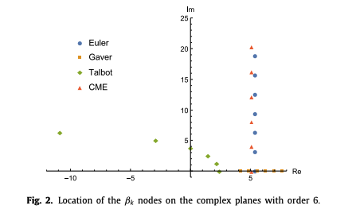

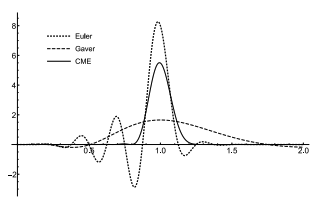

## Examples & advice

```julia
using Plots
include("ilt.jl")
ilt_methods = ["cme"; "talbot"; "euler"; "gaver"]
```

```
4-element Array{String,1}:
 "cme"
 "talbot"
 "euler"
 "gaver"
```

```julia
f(t) = t*exp(-t)
f̂(s) = 1/(s+1)^2
```

```
f̂ (generic function with 1 method)
```

\begin{equation} f(t) = t e^{-t} \end{equation}

```julia
plot(0:0.2:4,f,label="truth")
order = 3
for method in ilt_methods
    f_approx(t) = InverseLaplace.ilt(f̂,t,order,method)
    plot!(0:0.2:4,f_approx,label=method)
end
plot!()
```

[figure not shown]

\begin{equation} f(t) = 1(t>1)e^{-(t-1)} \end{equation}

```julia
f̂(s) = exp(-s)/(s+1)
f(t) = (t.>1)*exp(-(t-1))
order = 5
plot(0:0.1:4, f,label="truth",legend = :topright, title = "naive")
for method in ilt_methods
#     if method != "talbot"
        f_approx(t) = InverseLaplace.ilt(f̂,t,order ,method)
        plot!(0:0.05:4,f_approx,label=method)
#     end
end
p1 = plot!()
```

[figure not shown]

**Shift poles**

```julia
shift = -1
f̂_shift(s) = f̂(s + shift)
plot(0:0.1:4, f,label="truth",legend = :topright,title = "shift poles")
for method in ilt_methods
    if method != "talbot"
        f_approx(t) = exp(shift*t)*InverseLaplace.ilt(f̂_shift,t,order ,method)
        plot!(0:0.05:4,f_approx,label=method)
    end
end
p2 = plot!()
display(p1)
display(p2)
```

[figure not shown]

**Shift discontinuities** \begin{equation} \mathcal L\{1(t>a)f(t-a)\} = e^{-as}\widehat f(s) \end{equation} e.g. if \begin{equation} f(t) = 1(t>1)e^{-(t-1)} \end{equation} then \begin{equation} 1(t>1)f(t+1) = e^{-t} \end{equation} and \begin{equation} \mathcal L(s)\{1(t>1)f(t+1)\} = \frac{1}{s+1} \end{equation}

```julia
shift = -1
f̂_shift(s) = exp(-shift*s)*f̂(s)
plot(0:0.1:4, f,label="truth",legend = :topright, title = "shift discontinuity")
for method in ilt_methods
    f_approx(t) = InverseLaplace.ilt(f̂_shift,t+shift,order ,method)
    plot!(1:0.05:4,f_approx,label=method)
end
p3 = plot!()
display(p1)
display(p3)
```

[figure not shown]

**Shift both!**

```julia
shift = -1
f̂_shift(s) = exp(-shift*s)*f̂(s+shift)
plot(0:0.1:4, f,label="truth",legend = :topright, title = "low order, shift poles and discontinuity")
for method in ilt_methods
        f_approx(t) = exp(shift*t)*InverseLaplace.ilt(f̂_shift,t+shift,order ,method)
        plot!(1:0.05:4,f_approx,label=method)
end
p5 = plot!()
```

[figure not shown]

\begin{equation} f(t) = sin(πt) \end{equation}

```julia
f(t) = sin(π*t)
f̂(s) = π/(s^2+π^2)
order = 10
plot(0:0.1:4,f,label="truth",legend = :topright)
for method in ilt_methods
    if method != "talbot"
        f_approx(t) = InverseLaplace.ilt(f̂,t,order ,method)
        plot!(0:0.1:4,f_approx,label=method)
    end
end
plot!()
```

[figure not shown]

**Staircase function** \begin{equation} f(t) = \sum_{i=1}^\infty 1(t>i) \end{equation}

```julia
f̂(s) = (1/s)*(1/(exp(s)-1))
f(t) = sum(t.>0:4).-1
order = 10
plot(0:0.02:4,f,label="truth",legend = :topleft)
for method in ilt_methods
    if method != "talbot"
        f_approx(t) = InverseLaplace.ilt(f̂,t,order ,method)
        plot!(0:0.1:4,f_approx,label=method)
    end
end
plot!()
```

[figure not shown]

\begin{equation} f(t) = \delta(t-1) \end{equation}

```julia
f̂(s) = exp(-s)
order = 10
plot()
for method in ilt_methods
    if method != "talbot"
        f_approx(t) = InverseLaplace.ilt(f̂,t,order ,method)
        plot!(0:0.2:4,f_approx,label=method)
    end
end
plot!()
```

[figure not shown]

## Inversion by approximation by basis functions: Legendre Polynomials

- Legendre polynomials are orthogonal polynomials on $[-1,1]$.
- Map $[0,\infty)$ to $[0,1]$ via \begin{equation}

  ```
    x = e^{-\sigma t},\,\sigma>0.
  ```

  \end{equation}
- This gives \begin{equation}

  ```
    \widehat f(s) =  \int_{t=0}^\infty e^{-st}f(t) dt = \frac{1}{\sigma} \int_{x=0}^1 x ^{s/\sigma-1}f\left(\frac{1}{\sigma}\ln(x)\right)dx= \frac{1}{\sigma} \int_{x=0}^1 x ^{s/\sigma-1}g(x)dx
  ```

  \end{equation} so $f\left(\frac{1}{\sigma}\ln(x)\right)=g(x)$.
- Then map to $[-1,1]$ by defining \begin{equation}

  ```
    g(-x) = g(x).
  ```

  \end{equation}
- Approximate $g(x)$ by polynomials.  
  \begin{equation}

  ```
    g(x)\approx g_{n}(x) = \sum_{k=0}^n \alpha_k P_{2k}(x).
  ```

  \end{equation}
- Then, solve the system (note: Laplace transform domain) \begin{equation}

  ```
    \widehat f(t_i) = \sum_{k=0}^n \alpha_k \widehat P_{2k}(t_i),
  ```

  \end{equation} for some collection of points $x_1,\dots,x_n$.

```julia
using Plots

f(t) = t*exp(-t)
f̂(s) = 1/(s+1)^2

σ = 1
s = [σ;3*σ;5*σ]

A = [1 0 0; 1/3 2/(3*5) 0; 1/5 4/(5*7) 4*2/(5*7*9)]

α = A\f̂.(s)

# Legendre basis
P(x) = [1; 0.5*(3*x^2-1); 1/8*(35*x^4-30*x^2+3)]

f₃(t) = α'*P(exp(-t))
```

```
f₃ (generic function with 1 method)
```

```julia
plot(0:0.1:4,f,label="truth")
plot!(0:0.1:4,f₃,label="approx")
plot!(xlabel = "t", ylabel = "f(t), f₃(t)")
```

[figure not shown]

- Convergence can be slow, apparently.
- Also requires solving a system of equations
  - Consider the conditioning of matrix
  - Computations required to solve the system